# Practical ML Project

nkvasg

Friday, July 24, 2015

## Introduction

Using devices such as Jawbone Up, Nike FuelBand, and Fitbit, it is now possible to collect a large amount of data about personal activity relatively inexpensively. These type of devices are part of the quantified self movement - a group of enthusiasts who take measurements about themselves regularly to improve their health, to find patterns in their behavior, or because they are tech geeks. One thing that people regularly do is quantify how much of a particular activity they do, but they rarely quantify how well they do it.

The data used in this project are from accelerometers on the belt, forearm, arm, and dumbell of 6 participants. They were asked to perform barbell lifts correctly and incorrectly in 5 different ways.

The goal of this project is to predict the manner in which the participants did the exercise. This is the “classe” variable in the training set. Also to find out if any variables are of more importance to be used in the predictions. This report will go through the process of exploring and cleaning the dataset and build the training model. It also includes the training model, the cross validation results, sample errors and the predicted results for the test dataset using the selected model.

## Load the library

```r
library(caret)
library(randomForest)
```

## Load data

```r
train_data <- read.csv("pml-training.csv")
test_data <- read.csv("pml-testing.csv")
dim(train_data)
```

```
## [1] 19622   160
```

```r
dim(test_data)
```

```
## [1]  20 160
```

```r
head(train_data)
```

```
##   X user_name raw_timestamp_part_1 raw_timestamp_part_2   cvtd_timestamp
## 1 1  carlitos           1323084231               788290 05/12/2011 11:23
## 2 2  carlitos           1323084231               808298 05/12/2011 11:23
## 3 3  carlitos           1323084231               820366 05/12/2011 11:23
## 4 4  carlitos           1323084232               120339 05/12/2011 11:23
## 5 5  carlitos           1323084232               196328 05/12/2011 11:23
## 6 6  carlitos           1323084232               304277 05/12/2011 11:23
##   new_window num_window roll_belt pitch_belt yaw_belt total_accel_belt
## 1         no         11      1.41       8.07    -94.4                3
## 2         no         11      1.41       8.07    -94.4                3
## 3         no         11      1.42       8.07    -94.4                3
## 4         no         12      1.48       8.05    -94.4                3
## 5         no         12      1.48       8.07    -94.4                3
## 6         no         12      1.45       8.06    -94.4                3
##   kurtosis_roll_belt kurtosis_picth_belt kurtosis_yaw_belt
```

[output cut: 265 more lines]

```r
head(test_data)
```

```
##   X user_name raw_timestamp_part_1 raw_timestamp_part_2   cvtd_timestamp
## 1 1     pedro           1323095002               868349 05/12/2011 14:23
## 2 2    jeremy           1322673067               778725 30/11/2011 17:11
## 3 3    jeremy           1322673075               342967 30/11/2011 17:11
## 4 4    adelmo           1322832789               560311 02/12/2011 13:33
## 5 5    eurico           1322489635               814776 28/11/2011 14:13
## 6 6    jeremy           1322673149               510661 30/11/2011 17:12
##   new_window num_window roll_belt pitch_belt yaw_belt total_accel_belt
## 1         no         74    123.00      27.00    -4.75               20
## 2         no        431      1.02       4.87   -88.90                4
## 3         no        439      0.87       1.82   -88.50                5
## 4         no        194    125.00     -41.60   162.00               17
## 5         no        235      1.35       3.33   -88.60                3
## 6         no        504     -5.92       1.59   -87.70                4
##   kurtosis_roll_belt kurtosis_picth_belt kurtosis_yaw_belt
```

[output cut: 265 more lines]

## Clean data

```r
train_data <- train_data[, colSums(is.na(train_data)) == 0]
test_data <- test_data[, colSums(is.na(test_data)) == 0]

classe <- train_data$classe
train_rem <- grepl("^X|timestamp|window", names(train_data))
train_data <- train_data[, !train_rem]
train_cleaned <- train_data[, sapply(train_data, is.numeric)]
train_cleaned$classe <- classe
test_rem <- grepl("^X|timestamp|window", names(test_data))
test_data <- test_data[, !test_rem]
test_cleaned <- test_data[, sapply(test_data, is.numeric)]
dim(train_cleaned)
```

```
## [1] 19622    53
```

```r
dim(test_cleaned)
```

```
## [1] 20 53
```

## Produce train and test datasets, using 70% for training and 30% for cross validation

```r
set.seed(22519)
trainIndex <- createDataPartition(train_cleaned$classe, p=0.7, list=F)
train <- train_cleaned[trainIndex, ]
test <- train_cleaned[-trainIndex, ]
```

## Modelling an Predicting

The random forest algorithm is used because important variables can be automatically selected. 10-fold cross validation is used.

```r
rfmodel <- train(classe ~ ., data=train, method="rf", trControl=trainControl(method="cv", 10))
rfmodel
```

```
## Random Forest
##
## 13737 samples
##    52 predictor
##     5 classes: 'A', 'B', 'C', 'D', 'E'
##
## No pre-processing
## Resampling: Cross-Validated (10 fold)
##
## Summary of sample sizes: 12363, 12364, 12362, 12362, 12363, 12363, ...
##
## Resampling results across tuning parameters:
##
##   mtry  Accuracy   Kappa      Accuracy SD  Kappa SD
##    2    0.9930838  0.9912506  0.002009678  0.002542853
##   27    0.9930115  0.9911593  0.002456128  0.003107940
##   52    0.9865335  0.9829625  0.004693912  0.005940221
##
## Accuracy was used to select the optimal model using  the largest value.
## The final value used for the model was mtry = 2.
```

```r
prediction <- predict(rfmodel, test)
cm <- confusionMatrix(test$classe, prediction)
error <- 1 - as.numeric(cm$overall[1])
error
```

```
## [1] 0.006627018
```

## Look at the important variables

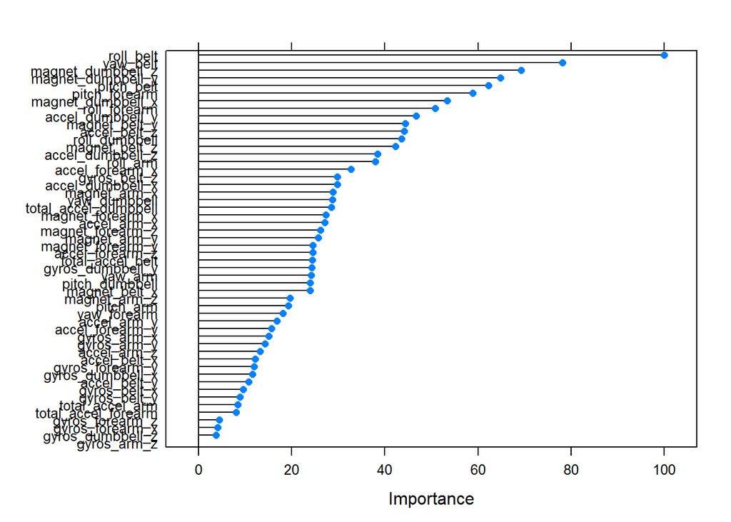

```r
plot(varImp(rfmodel))
```

## Make predictions for the test set

```r
result <- predict(rfmodel, test_cleaned[, -length(names(test_cleaned))])
result
```

```
##  [1] B A B A A E D B A A B C B A E E A B B B
## Levels: A B C D E
```